# Figure 7B — Three-chamber Social Interaction Test (SIT)

Time spent in the **stranger-mouse** vs **novel-object** chamber for the four perinatal-insult groups: **Sal-N**, **Sal-Hx**, **LPS-N**, **LPS-Hx**.

**Statistical test.** Within each group, a **two-sided paired Wilcoxon signed-rank test** compares stranger-mouse time vs novel-object time per animal (Pratt method for zero differences, continuity-corrected normal approximation). Effect size reported as **r = |Z| / √n**. Raw p-values are adjusted across the four within-group tests by **Benjamini–Hochberg FDR**, and the significance markers in the figure refer to the adjusted p. Markers: `*` p < 0.05, `**` p < 0.01, `***` p < 0.001.

```python
import os, re, csv
import numpy as np
import pandas as pd
import matplotlib.pyplot as plt
import matplotlib.patches as mpatches
from scipy import stats
from IPython.display import display

plt.rcParams["font.family"] = "Arial"

DATA = "data/combined_chamber_time.csv"
df = pd.read_csv(DATA)

# Group naming matches the manuscript figures.
GROUP_ORDER = ["Sal-N", "Sal-Hx", "LPS-N", "LPS-Hx"]
GROUP_FILL  = {"Sal-N":  "#9E9E9E",   # grey
               "Sal-Hx": "#F5B7B1",   # pink
               "LPS-N":  "#A6E0C8",   # mint
               "LPS-Hx": "#C5B7E0"}   # lavender

df = df[df["group"].isin(GROUP_ORDER)].copy()
df["group"] = pd.Categorical(df["group"], categories=GROUP_ORDER, ordered=True)
```

## SIT — Sample sizes per group

```python
n_tab = (df.groupby("group", observed=True).size()
           .rename("n").reset_index().rename(columns={"group": "Group"}))
n_tab.loc[len(n_tab)] = ["Total", int(n_tab["n"].sum())]
display(n_tab.style.hide(axis="index")
        .set_caption("Per-group sample size in the Fig 7B SIT panel."))
```

Per-group sample size in the Fig 7B SIT panel.

| Group | n |
| --- | --- |
| Sal-N | 15 |
| Sal-Hx | 6 |
| LPS-N | 13 |
| LPS-Hx | 11 |
| Total | 45 |

## SIT — Per-group paired Wilcoxon (stranger vs novel object)

```python
def stars(p):
    return ("***" if p < 0.001 else "**" if p < 0.01
            else "*" if p < 0.05 else "ns")

# Two-sided paired Wilcoxon signed-rank test (scipy default: zsplit ties,
# Pratt method exclude zero-diffs, exact for small n, normal-approx with
# continuity correction otherwise). Effect size r = |Z| / sqrt(N).
# Multiple-comparison adjustment across the 4 within-group tests using
# Benjamini-Hochberg FDR.
from scipy.stats import norm
from statsmodels.stats.multitest import multipletests

rows = []
for g in GROUP_ORDER:
    sub = df[df["group"] == g]
    S = sub["stranger_s"].to_numpy()
    O = sub["object_s"].to_numpy()
    res = stats.wilcoxon(S, O, alternative="two-sided",
                         zero_method="pratt", correction=True,
                         method="approx")        # forces z-score reporting
    W  = float(res.statistic)
    p  = float(res.pvalue)
    z  = float(norm.isf(p / 2)) * (1 if np.median(S - O) >= 0 else -1)
    r  = abs(z) / np.sqrt(len(S))
    rows.append({"Group": g, "n": len(S),
                 "Stranger median (s)": round(float(np.median(S)), 1),
                 "Object median (s)":   round(float(np.median(O)), 1),
                 "W":                   round(W, 1),
                 "|Z|":                 round(abs(z), 2),
                 "Effect size r":       round(r, 2),
                 "Wilcoxon p (raw)":    f"{p:.4f}"})

within_tab = pd.DataFrame(rows)

# BH-FDR across the four within-group tests.
_, p_adj, _, _ = multipletests(
    within_tab["Wilcoxon p (raw)"].astype(float).to_numpy(),
    method="fdr_bh")
within_tab["p (BH-FDR)"]  = [f"{p:.4f}" for p in p_adj]
within_tab["Significance"] = [stars(p) for p in p_adj]

display(within_tab.style.hide(axis="index")
        .set_caption("Within-group paired Wilcoxon signed-rank tests "
                     "(stranger vs novel-object chamber time). "
                     "Two-sided, Pratt zero-method, continuity-corrected normal "
                     "approximation. Effect size r = |Z|/√n. "
                     "p-values adjusted across 4 groups by Benjamini-Hochberg "
                     "FDR; significance markers refer to the BH-adjusted p."))
```

Within-group paired Wilcoxon signed-rank tests (stranger vs novel-object chamber time). Two-sided, Pratt zero-method, continuity-corrected normal approximation. Effect size r = |Z|/√n. p-values adjusted across 4 groups by Benjamini-Hochberg FDR; significance markers refer to the BH-adjusted p.

| Group | n | Stranger median (s) | Object median (s) | W | \|Z\| | Effect size r | Wilcoxon p (raw) | p (BH-FDR) | Significance |
| --- | --- | --- | --- | --- | --- | --- | --- | --- | --- |
| Sal-N | 15 | 159.000000 | 21.700000 | 2.000000 | 3.270000 | 0.840000 | 0.0011 | 0.0044 | ** |
| Sal-Hx | 6 | 46.700000 | 77.200000 | 8.000000 | 0.420000 | 0.170000 | 0.6750 | 0.6750 | ns |
| LPS-N | 13 | 99.500000 | 49.300000 | 4.000000 | 2.870000 | 0.790000 | 0.0042 | 0.0068 | ** |
| LPS-Hx | 11 | 152.900000 | 11.400000 | 1.000000 | 2.800000 | 0.840000 | 0.0051 | 0.0068 | ** |

## SIT — Chamber-time distribution

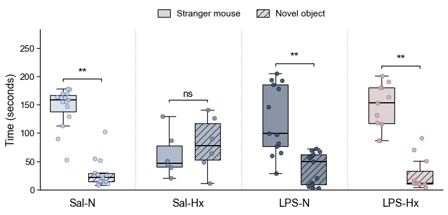

```python
# Fig 7B (publication panel): two boxes per group (Stranger solid / Novel-object
# hatched), group colours = paper-wide palette, within-group Stranger-vs-Object
# significance brackets (BH-FDR-adjusted p). Sized to the 3.82:1.95 aspect ratio
# (SCALE x base) -- change SCALE only; the ratio stays fixed.
from matplotlib.colors import to_rgba

ASPECT_W, ASPECT_H = 3.82, 1.95     # target aspect ratio
SCALE = 2.0                          # bigger render, same ratio
FIG_W, FIG_H = ASPECT_W * SCALE, ASPECT_H * SCALE
plt.rcParams["hatch.linewidth"] = 0.6

CHAMBERS = [
    ("stranger_s", "Stranger mouse"),   # solid fill
    ("object_s",   "Novel object"),     # hatched fill
]
OBJECT_HATCH = "///"

# Paper-wide group palette (matches Fig 6E/F & Fig 7D): light box fill + darker dots.
GROUP_FILL = {"Sal-N": "#C6D0E2", "Sal-Hx": "#7A8FA8",
              "LPS-N": "#3A4D68", "LPS-Hx": "#C8B8BC"}
GROUP_DOT  = {"Sal-N": "#4A6FA5", "Sal-Hx": "#2C4A6E",
              "LPS-N": "#0D1F38", "LPS-Hx": "#A55C66"}

# Layout (data x-units; auto-scales to the physical width)
box_w   = 0.24
gap_in  = 0.12
gap_grp = 0.40
pitch   = box_w + gap_in
group_w = 2 * box_w + gap_in

xs_by_group = []
group_left  = 0.0
for _ in GROUP_ORDER:
    left = group_left
    xs_by_group.append([left + 0.5*box_w + k*pitch for k in range(2)])
    group_left = left + group_w + gap_grp

y_top_global = max(df[col].max() for col, _ in CHAMBERS)
y_lim_top    = y_top_global * 1.38

fig, ax = plt.subplots(figsize=(FIG_W, FIG_H), facecolor="white")

# Boxes + jitter dots
for gi, g in enumerate(GROUP_ORDER):
    sub = df[df["group"] == g]
    xs  = xs_by_group[gi]
    for ci, (col, name) in enumerate(CHAMBERS):
        vals = sub[col].dropna().to_numpy()
        boxprops = dict(facecolor=to_rgba(GROUP_FILL[g], 0.60),
                        edgecolor="black", linewidth=0.9)
        if ci == 1:                       # novel-object box -> hatched
            boxprops["hatch"] = OBJECT_HATCH
        ax.boxplot(
            [vals], positions=[xs[ci]], widths=box_w,
            patch_artist=True, showfliers=False,
            medianprops=dict(color="black", linewidth=1.4),
            whiskerprops=dict(color="black", linewidth=0.9),
            capprops=dict(color="black", linewidth=0.9),
            boxprops=boxprops,
        )
        rng = np.random.default_rng(42 + 7*gi + ci)
        jx  = xs[ci] + (rng.random(len(vals)) - 0.5) * box_w * 0.55
        ax.scatter(jx, vals, s=24, alpha=0.90, zorder=3,
                   facecolor=GROUP_FILL[g], edgecolor=GROUP_DOT[g], linewidth=0.6)

# Group labels below the boxes
group_centers = [float(np.mean(xs)) for xs in xs_by_group]
for cx, g in zip(group_centers, GROUP_ORDER):
    ax.text(cx, -y_lim_top * 0.055, g,
            ha="center", va="top", fontsize=13)

# Dotted vertical separators between groups
for i in range(len(GROUP_ORDER) - 1):
    sep_x = (xs_by_group[i][-1] + xs_by_group[i+1][0]) / 2
    ax.axvline(sep_x, color="#777777", linestyle=":", linewidth=0.8, alpha=0.7)

# Within-group significance brackets (BH-FDR-adjusted p)
sig_map = {row["Group"]: row["Significance"] for _, row in within_tab.iterrows()}
for gi, g in enumerate(GROUP_ORDER):
    xs = xs_by_group[gi]
    x_soc, x_obj = xs[0], xs[1]
    sub  = df[df["group"] == g]
    bar_y = max(sub["stranger_s"].max(),
                sub["object_s"].max()) + y_lim_top * 0.05
    tick  = y_lim_top * 0.012
    ax.plot([x_soc, x_soc, x_obj, x_obj],
            [bar_y, bar_y + tick, bar_y + tick, bar_y],
            color="black", linewidth=1.0)
    txt = sig_map[g]
    ax.text((x_soc + x_obj) / 2, bar_y + tick * 1.6, txt,
            ha="center", va="bottom",
            fontsize=14 if txt != "ns" else 12,
            fontweight="normal")

# Top legend: fill-style key (solid = stranger, hatched = novel object).
legend_handles = [
    mpatches.Patch(facecolor="#D9D9D9", edgecolor="black", linewidth=0.9,
                   label="Stranger mouse"),
    mpatches.Patch(facecolor="#D9D9D9", edgecolor="black", linewidth=0.9,
                   hatch=OBJECT_HATCH, label="Novel object"),
]
ax.legend(handles=legend_handles, loc="lower center",
          bbox_to_anchor=(0.5, 1.02), ncol=2,
          frameon=False, fontsize=11, handlelength=1.4,
          handleheight=1.0, columnspacing=1.8, handletextpad=0.7,
          borderpad=0.4)

# Axes / chrome
all_xs = [x for xs in xs_by_group for x in xs]
ax.set_xlim(min(all_xs) - box_w*0.9, max(all_xs) + box_w*0.9)
ax.set_ylim(0, y_lim_top)
ax.set_xticks([])
ax.set_ylabel("Time (seconds)", fontsize=13)
ax.tick_params(axis="y", labelsize=11, length=4, width=0.9, pad=2.5)
for side in ("top", "right"):
    ax.spines[side].set_visible(False)
ax.spines["left"].set_linewidth(1.0)
ax.spines["bottom"].set_linewidth(1.0)

# Fixed margins -> output is exactly FIG_W x FIG_H (aspect ratio stays exact).
fig.subplots_adjust(left=0.09, right=0.985, top=0.83, bottom=0.13)

fig.savefig("Fig7B.pdf", facecolor="white")            # vector
fig.savefig("Fig7B.png", dpi=600, facecolor="white")   # high-res raster
plt.show()
```

> **Footer.** Brackets show within-group paired Wilcoxon signed-rank tests (stranger-mouse vs novel-object chamber time). Two-sided, Pratt zero-method, continuity-corrected normal approximation; effect size r = |Z|/√n. p-values BH-FDR–adjusted across the four groups; figure markers refer to the adjusted p. `*` p < 0.05, `**` p < 0.01, `***` p < 0.001.

## SIT — Full per-recording dataset (sortable / searchable)

Every row used to build the boxplot above. Use the **Search** box to filter (e.g. type `Sal-N` or part of a recording ID) and click any column header to sort.

> **Note on the apparent dot-count mismatch in Sal-N.** The data has **n = 15** valid stranger/object pairs for Sal-N — no NaN, no zeros. The reason the Object box looks like it has only ~13 dots is that 7 of the 15 animals cluster in a very narrow band (≈ 8–17 s) at the bottom of the Object box; the jittered markers overlap and visually merge. The sortable table below confirms all 15 paired values.

```python
from itables import init_notebook_mode, show
init_notebook_mode(all_interactive=False)   # only the calls below render interactively

tbl = (df.assign(
          stranger_s=lambda d: d['stranger_s'].round(1),
          object_s=lambda d: d['object_s'].round(1),
          middle_s=lambda d: d['middle_s'].round(1))
         .rename(columns={
             'group':        'Group',
             'recording_id': 'Recording',
             'cohort':       'Cohort',
             'stranger_s':   'Stranger time (s)',
             'object_s':     'Object time (s)',
             'middle_s':     'Empty-chamber time (s)',
             'window_s':     'Assay window (s)',
             'rescaled':     'Rescaled?'})
         .loc[:, ['Group', 'Recording', 'Cohort',
                  'Stranger time (s)', 'Object time (s)',
                  'Empty-chamber time (s)', 'Assay window (s)',
                  'Rescaled?']]
         .sort_values(['Group', 'Recording'], kind='stable')
         .reset_index(drop=True))

show(tbl,
     classes='display compact',
     paging=True,
     pageLength=10,
     scrollX=True,
     search={'regex': True, 'caseInsensitive': True},
     order=[[0, 'asc'], [1, 'asc']],
     caption='Per-recording chamber-time data underlying Fig 7B. '
             'All n=15 Sal-N animals have valid Stranger and Object values; '
             'sort the Object-time column to see the cluster of low values '
             'that overlap in the figure jitter.')
```

[figure not shown]

Loading ITables v2.8.0 from the `init_notebook_mode` cell... (need [help](https://mwouts.github.io/itables/troubleshooting.html)?)

# Part 2 — Reviewer comments on Fig 7B

## Comment R1-A — Bimodality in the Sal-N SIT group

> *"Figure 7C: The saline-normoxia control group looks like it could be divided into a subgroup that spent a lot of time with the novel mouse and a subgroup that spent very little time with the novel mouse. What might be the reason for this distribution?"* — **Referee 1**

**What we did.** Hartigan's dip test for unimodality applied to the Sal-N stranger-mouse-time values, plus a histogram of the raw values.

Sal-N stranger-mouse times (seconds), sorted.

| Recording | Stranger time (s) |
| --- | --- |
| 2021-11-23T13_03_03 | 52.416667 |
| 2021-12-13T14_29_12 | 90.488095 |
| 2021-11-08T13_43_36 | 113.238095 |
| Test2022-03-15T12_12_40 | 129.013600 |
| 2021-12-13T13_43_32 | 146.785714 |
| Test2022-03-14T15_32_07 | 155.323100 |
| 2021-11-05T15_16_14 | 155.357143 |
| 2021-11-09T11_23_06 | 158.976191 |
| Test2022-03-15T13_20_38 | 162.287400 |
| Test2022-03-14T14_56_56 | 162.597800 |
| 2021-11-08T11_48_55 | 163.523809 |
| 2021-11-05T14_34_57 | 169.416667 |
| 2021-12-13T15_04_53 | 170.273809 |
| 2021-11-09T10_46_50 | 177.130952 |
| Test2022-03-15T13_55_06 | 177.827400 |

```
Hartigan's dip test:  D = 0.066,  p = 0.8614  →  unimodality cannot be rejected.
```

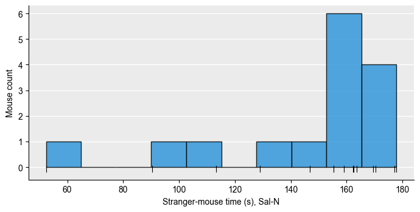

```python
from diptest import diptest

saln = (df[df["group"] == "Sal-N"][["recording_id", "stranger_s"]]
          .sort_values("stranger_s")
          .rename(columns={"recording_id": "Recording",
                           "stranger_s": "Stranger time (s)"}))
display(saln.style.hide(axis="index")
              .set_caption("Sal-N stranger-mouse times (seconds), sorted."))

D, p = diptest(saln["Stranger time (s)"].to_numpy())
verdict = ("bimodality is statistically supported" if p < 0.05
           else "unimodality cannot be rejected")
print(f"Hartigan's dip test:  D = {D:.3f},  p = {p:.4f}  →  {verdict}.")

fig, ax = plt.subplots(figsize=(7, 3.6), facecolor="white")
ax.hist(saln["Stranger time (s)"], bins=10, color="#3498db",
        edgecolor="black", alpha=0.85)
for v in saln["Stranger time (s)"]:
    ax.plot([v, v], [-0.18, 0.05], color="black", linewidth=0.8, clip_on=False)
ax.set_xlabel("Stranger-mouse time (s), Sal-N")
ax.set_ylabel("Mouse count")
ax.set_facecolor("#ebebeb")
for s in ("top", "right"):
    ax.spines[s].set_visible(False)
ax.yaxis.grid(True, color="white", linewidth=1.0)
ax.set_axisbelow(True)
plt.tight_layout()
plt.show()
```

## Comment R1-C (SIT-relevant) — Sex of test and novel mice

> *"What was the sex of the novel mouse? If the novel mouse was kept consistent across all animals, are there differences in the behavior depending on the sex of the test animal?"* — **Referee 1**

**Feasibility: partially doable from data; otherwise needs lab records.** A subset of recording IDs encodes test-animal sex with an `M`/`F` prefix (`M1, M2, ... ; F1, F2, ...`). Where the prefix is present we extract sex directly from the filename. The rest of the recordings use timestamp-only naming and the test-animal sex cannot be recovered from the data files — nor can the **sex of the novel stimulus mouse** itself, which is not present in the DLC output at all. Resolving these requires the lab animal-list.

```python
sex_pat = re.compile(r'(?<![A-Za-z])([MF])(?=[0-9])')

def extract_sex(rid):
    m = sex_pat.search(str(rid))
    return m.group(1) if m else None

sex_df = df[["group", "recording_id"]].copy()
sex_df["Sex"] = sex_df["recording_id"].map(extract_sex)
sex_df = sex_df.rename(columns={"group": "Group", "recording_id": "Recording"})

display(sex_df.style.hide(axis="index")
       .set_caption("SIT animal IDs with sex extracted where the ID encodes it "
                    "(blank = not encoded in filename)."))

cov = (sex_df.assign(M=(sex_df["Sex"]=="M").astype(int),
                     F=(sex_df["Sex"]=="F").astype(int),
                     sex_unknown=sex_df["Sex"].isna().astype(int))
              .groupby("Group", observed=True)
              .agg(n=("Group", "size"),
                   male=("M", "sum"),
                   female=("F", "sum"),
                   sex_unknown=("sex_unknown", "sum"))
              .reindex(GROUP_ORDER)
              .reset_index())
display(cov.style.hide(axis="index")
       .set_caption("Per-group sex coverage recoverable from animal IDs (SIT). "
                    "Sex of the novel stimulus mouse is not in the data."))
```

SIT animal IDs with sex extracted where the ID encodes it (blank = not encoded in filename).

| Group | Recording | Sex |
| --- | --- | --- |
| Sal-N | 2021-11-05T14_34_57 | None |
| Sal-N | 2021-11-08T13_43_36 | None |
| Sal-N | 2021-11-09T11_23_06 | None |
| Sal-N | 2021-11-05T15_16_14 | None |
| Sal-N | 2021-11-08T11_48_55 | None |
| Sal-N | 2021-11-09T10_46_50 | None |
| Sal-N | 2021-11-23T13_03_03 | None |
| Sal-N | 2021-12-13T13_43_32 | None |
| Sal-N | 2021-12-13T14_29_12 | None |
| Sal-N | 2021-12-13T15_04_53 | None |
| Sal-Hx | 2021-11-05T15_56_07 | None |
| Sal-Hx | 2021-11-08T12_29_52 | None |
| Sal-Hx | 2021-11-24T13_28_05 | None |
| Sal-Hx | 2021-11-08T13_08_11 | None |
| Sal-Hx | 2021-11-24T14_03_46 | None |
| LPS-N | 2021-11-23T11_51_08 | None |
| LPS-N | 2021-12-07T15_14_44 | None |
| LPS-N | 2021-12-07T15_50_56 | None |
| LPS-N | 2021-11-23T12_27_10 | None |
| LPS-N | 2021-12-07T16_28_31 | None |
| LPS-N | 2021-12-08T10_29_27 | None |
| LPS-N | 2021-12-08T11_05_46 | None |
| LPS-N | 2021-12-08T11_44_29 | None |
| LPS-Hx | 2021-11-22T12_01_59 | None |
| LPS-Hx | 2021-11-22T12_38_28 | None |
| LPS-Hx | 2021-11-22T13_17_09 | None |
| LPS-Hx | control2022-02-23T10_57_00 | None |
| LPS-Hx | control2022-02-24T13_49_27 | None |
| LPS-Hx | control2022-02-23T10_18_32 | None |
| LPS-Hx | control2022-02-24T13_14_24 | None |
| LPS-Hx | control2022-02-24T12_39_41 | None |
| LPS-Hx | control2022-02-24T14_23_56 | None |
| LPS-Hx | control2022-02-23T11_36_07 | None |
| LPS-Hx | control2022-02-25T15_44_07 | None |
| Sal-Hx | test2021-11-24T12_50_23 | None |
| LPS-N | LPS_NoPT_NoEE_M12024-06-28T08_46_33 | M |
| LPS-N | LPS_NoPT_NoEE_M22024-06-28T09_41_21 | M |
| LPS-N | LPS_NoPT_NoEE_F22024-06-28T11_12_29 | F |
| LPS-N | LPS_NoPT_NoEE_F12024-06-28T10_42_22 | F |
| LPS-N | LPS_NoPT_NoEE_M32024-06-28T10_12_31 | M |
| Sal-N | Test2022-03-14T14_56_56 | None |
| Sal-N | Test2022-03-15T12_12_40 | None |
| Sal-N | Test2022-03-15T13_20_38 | None |
| Sal-N | Test2022-03-15T13_55_06 | None |
| Sal-N | Test2022-03-14T15_32_07 | None |

Per-group sex coverage recoverable from animal IDs (SIT). Sex of the novel stimulus mouse is not in the data.

| Group | n | male | female | sex_unknown |
| --- | --- | --- | --- | --- |
| Sal-N | 15 | 0 | 0 | 15 |
| Sal-Hx | 6 | 0 | 0 | 6 |
| LPS-N | 13 | 3 | 2 | 8 |
| LPS-Hx | 11 | 0 | 0 | 11 |

## Comment R1-D (SIT-relevant) — Sample size after exclusion

> *"Would be useful to have n of each experimental group in behavioural and social experiments after exclusion."* — **Referee 1**

The figure uses the post-exclusion sample. Exclusions are pre-registered: duplicate videos (same recording present twice across cohorts), a tracking-failure recording, and two low-quality / low-social recordings flagged on quality-control review. The full exclusion manifest with reasons lives in `data/exclusions.csv`. Counts below are after all exclusions are applied.

```python
n_after = (df.groupby("group", observed=True).size()
             .rename("n").reset_index().rename(columns={"group": "Group"}))
n_after.loc[len(n_after)] = ["Total", int(n_after["n"].sum())]
display(n_after.style.hide(axis="index")
        .set_caption("Per-group n in the Fig 7B SIT panel after exclusion."))
```

Per-group n in the Fig 7B SIT panel after exclusion.

| Group | n |
| --- | --- |
| Sal-N | 15 |
| Sal-Hx | 6 |
| LPS-N | 13 |
| LPS-Hx | 11 |
| Total | 45 |

## Appendix — Data provenance check

```python
ex = pd.read_csv("data/exclusions.csv")
prov = pd.DataFrame({
    "Quantity": [
        "Rows in combined_chamber_time.csv (post-exclusion)",
        "Rows in exclusions.csv (manifest of removed recordings)",
        "Recordings excluded as duplicates",
        "Recordings excluded for tracking / quality reasons",
    ],
    "Value": [
        len(df),
        len(ex),
        int(ex["reason"].str.contains("duplicate", case=False).sum()),
        int(ex["reason"].str.contains("pre-registered", case=False).sum()),
    ],
})
display(prov.style.hide(axis="index").set_caption("Provenance counts."))
display(ex[["group", "recording_id", "reason"]].rename(
        columns={"group": "Group", "recording_id": "Recording", "reason": "Reason"})
        .style.hide(axis="index")
        .set_caption("Exclusion manifest (full list)."))
```

Provenance counts.

| Quantity | Value |
| --- | --- |
| Rows in combined_chamber_time.csv (post-exclusion) | 45 |
| Rows in exclusions.csv (manifest of removed recordings) | 8 |
| Recordings excluded as duplicates | 5 |
| Recordings excluded for tracking / quality reasons | 3 |

Exclusion manifest (full list).

| Group | Recording | Reason |
| --- | --- | --- |
| Sal-Hx | test2021-11-08T12_29_52 | duplicate video already in another cohort (dedup) |
| Sal-Hx | test2021-11-08T13_08_11 | duplicate video already in another cohort (dedup) |
| Sal-Hx | test2021-11-24T13_28_05 | duplicate video already in another cohort (dedup) |
| Sal-Hx | test2021-11-24T14_03_46 | duplicate video already in another cohort (dedup) |
| Sal-Hx | test2021-11-05T15_56_07 | duplicate video already in another cohort (dedup) |
| Sal-N | Test2022-03-14T14_16_43 | Pre-registered exclusion (1 tracking artifact + 2 low-quality/low-social) |
| Sal-N | Test2022-03-15T12_46_23 | Pre-registered exclusion (1 tracking artifact + 2 low-quality/low-social) |
| Sal-N | Test2022-03-14T13_41_12 | Pre-registered exclusion (1 tracking artifact + 2 low-quality/low-social) |